# Machine Learning Course Project

Dan Killian

March 11, 2016

One thing that people regularly do is quantify how much of a particular activity they do, but they rarely quantify how well they do it. In this project, we will use data from accelerometers on the belt, forearm, arm, and dumbell of 6 participants to predict what type of movement they are performing. This report will describe how we built our model(s), how we used cross validation, the expected out of sample error, and why we made the choices we did. Our model will then be used to predict 20 different test cases.

Read in and examine the data

```r
test <- read.csv("pml-testing.csv")
train <- read.csv("pml-training.csv")

test <- test[,2:159]
names(test)
```

```
##   [1] "user_name"                "raw_timestamp_part_1"
##   [3] "raw_timestamp_part_2"     "cvtd_timestamp"
##   [5] "new_window"               "num_window"
##   [7] "roll_belt"                "pitch_belt"
##   [9] "yaw_belt"                 "total_accel_belt"
##  [11] "kurtosis_roll_belt"       "kurtosis_picth_belt"
##  [13] "kurtosis_yaw_belt"        "skewness_roll_belt"
##  [15] "skewness_roll_belt.1"     "skewness_yaw_belt"
##  [17] "max_roll_belt"            "max_picth_belt"
##  [19] "max_yaw_belt"             "min_roll_belt"
##  [21] "min_pitch_belt"           "min_yaw_belt"
##  [23] "amplitude_roll_belt"      "amplitude_pitch_belt"
##  [25] "amplitude_yaw_belt"       "var_total_accel_belt"
##  [27] "avg_roll_belt"            "stddev_roll_belt"
##  [29] "var_roll_belt"            "avg_pitch_belt"
```

[output cut: 64 more lines]

```r
train <- train[,2:160]
train <- select(train, classe, everything())
train[1:5,1:5]
```

```
##   classe user_name raw_timestamp_part_1 raw_timestamp_part_2
## 1      A  carlitos           1323084231               788290
## 2      A  carlitos           1323084231               808298
## 3      A  carlitos           1323084231               820366
## 4      A  carlitos           1323084232               120339
## 5      A  carlitos           1323084232               196328
##     cvtd_timestamp
## 1 05/12/2011 11:23
## 2 05/12/2011 11:23
## 3 05/12/2011 11:23
## 4 05/12/2011 11:23
## 5 05/12/2011 11:23
```

```r
names(train)
```

```
##   [1] "classe"                   "user_name"
##   [3] "raw_timestamp_part_1"     "raw_timestamp_part_2"
##   [5] "cvtd_timestamp"           "new_window"
##   [7] "num_window"               "roll_belt"
##   [9] "pitch_belt"               "yaw_belt"
##  [11] "total_accel_belt"         "kurtosis_roll_belt"
##  [13] "kurtosis_picth_belt"      "kurtosis_yaw_belt"
##  [15] "skewness_roll_belt"       "skewness_roll_belt.1"
##  [17] "skewness_yaw_belt"        "max_roll_belt"
##  [19] "max_picth_belt"           "max_yaw_belt"
##  [21] "min_roll_belt"            "min_pitch_belt"
##  [23] "min_yaw_belt"             "amplitude_roll_belt"
##  [25] "amplitude_pitch_belt"     "amplitude_yaw_belt"
##  [27] "var_total_accel_belt"     "avg_roll_belt"
##  [29] "stddev_roll_belt"         "var_roll_belt"
```

[output cut: 65 more lines]

```r
names(train)[2:159]==names(test)
```

```
##   [1] TRUE TRUE TRUE TRUE TRUE TRUE TRUE TRUE TRUE TRUE TRUE TRUE TRUE TRUE
##  [15] TRUE TRUE TRUE TRUE TRUE TRUE TRUE TRUE TRUE TRUE TRUE TRUE TRUE TRUE
##  [29] TRUE TRUE TRUE TRUE TRUE TRUE TRUE TRUE TRUE TRUE TRUE TRUE TRUE TRUE
##  [43] TRUE TRUE TRUE TRUE TRUE TRUE TRUE TRUE TRUE TRUE TRUE TRUE TRUE TRUE
##  [57] TRUE TRUE TRUE TRUE TRUE TRUE TRUE TRUE TRUE TRUE TRUE TRUE TRUE TRUE
##  [71] TRUE TRUE TRUE TRUE TRUE TRUE TRUE TRUE TRUE TRUE TRUE TRUE TRUE TRUE
##  [85] TRUE TRUE TRUE TRUE TRUE TRUE TRUE TRUE TRUE TRUE TRUE TRUE TRUE TRUE
##  [99] TRUE TRUE TRUE TRUE TRUE TRUE TRUE TRUE TRUE TRUE TRUE TRUE TRUE TRUE
## [113] TRUE TRUE TRUE TRUE TRUE TRUE TRUE TRUE TRUE TRUE TRUE TRUE TRUE TRUE
## [127] TRUE TRUE TRUE TRUE TRUE TRUE TRUE TRUE TRUE TRUE TRUE TRUE TRUE TRUE
## [141] TRUE TRUE TRUE TRUE TRUE TRUE TRUE TRUE TRUE TRUE TRUE TRUE TRUE TRUE
## [155] TRUE TRUE TRUE TRUE
```

The “classe” variable is the type of movement that is being performed.

```
## -------------------------------------------------------------------------
## train$classe (factor)
##
##   length      n    NAs levels unique  dupes
##   19'622 19'622      0      5      5      y
##
##    level   freq   perc  cumfreq  cumperc
## 1      A  5'580  28.4%    5'580    28.4%
## 2      B  3'797  19.4%    9'377    47.8%
## 3      E  3'607  18.4%   12'984    66.2%
## 4      C  3'422  17.4%   16'406    83.6%
## 5      D  3'216  16.4%   19'622   100.0%
```

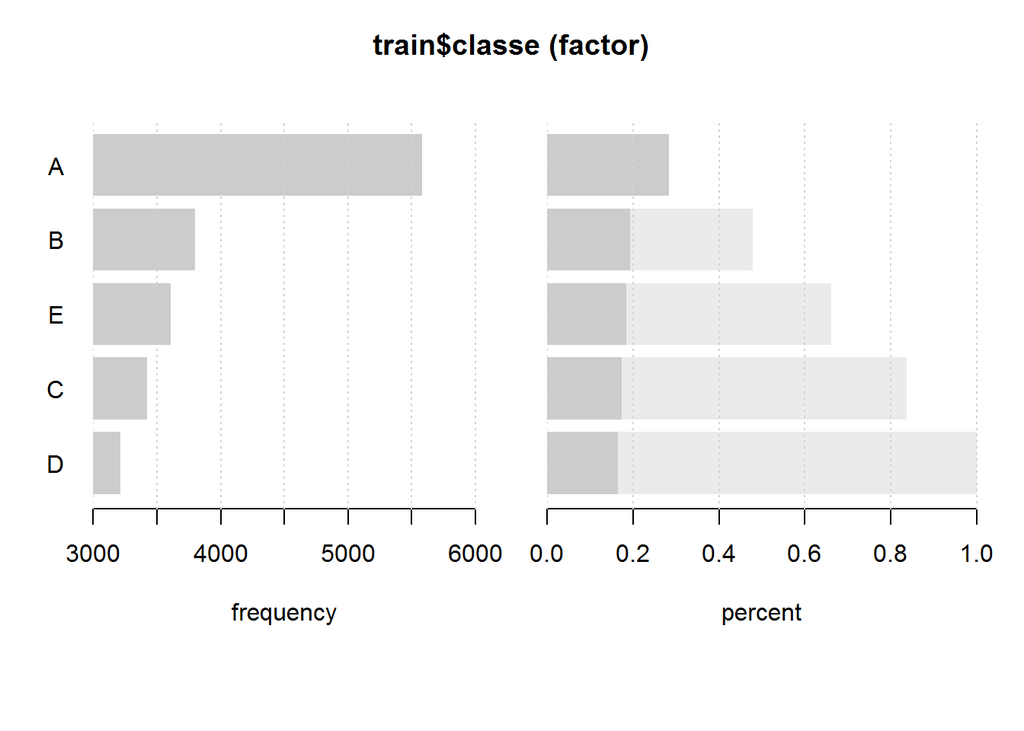

```r
Desc(train$classe, plotit=T)
```

There are five classes of movement. Movement A is most frequent at nearly 30 percent, while movements B-E range from 16-20 percent.

Additional visual inspection of the data reveals a lot of variables with missing values. Let’s remove variables with many missing values.

```r
train <- select(train, classe:total_accel_belt, gyros_belt_x:total_accel_arm, gyros_arm_x:magnet_arm_z, roll_dumbbell:yaw_dumbbell)

test <- select(test, user_name:total_accel_belt, gyros_belt_x:total_accel_arm, gyros_arm_x:magnet_arm_z, roll_dumbbell:yaw_dumbbell)
```

We pared down to a much more manageable 35 predictor variables. Now let’s train a linear discriminant analysis prediction model.

```
## Linear Discriminant Analysis
##
## 19622 samples
##    35 predictor
##     5 classes: 'A', 'B', 'C', 'D', 'E'
##
## No pre-processing
## Resampling: Bootstrapped (25 reps)
## Summary of sample sizes: 19622, 19622, 19622, 19622, 19622, 19622, ...
## Resampling results
##
##   Accuracy  Kappa  Accuracy SD  Kappa SD
##   0.785     0.73   0.00552      0.00694
##
##
```

79% in-sample accuracy. When I predicted the 20 test cases in the quiz portion, I got an out-of-sample accuracy of 85%, go figure.